# dynamichazard Dynamic Hazard Models using State Space Models

Benjamin Christoffersen  
16/03/2017

\[ \newcommand{\mat}[1]{\mathbf{#1}} % \newcommand{\Lparen}[1]{\left( #1\right)} \newcommand{\Lbrack}[1]{\left[ #1\right]} \newcommand{\Lbrace}[1]{\left \{ #1\right \}} \newcommand{\Lceil}[1]{\left \lceil #1\right \rceil} \newcommand{\Lfloor}[1]{\left \lfloor #1\right \rfloor} % \newcommand{\propp}[1]{P\Lparen{#1}} \newcommand{\proppCond}[2]{P\Lparen{\left. #1 \right\vert #2}} % \newcommand{\expecp}[1]{E\Lparen{#1}} \newcommand{\expecpCond}[2]{E\Lparen{\left. #1 \right\vert #2}} % \newcommand{\varp}[1]{\textrm{Var}\Lparen{#1}} \newcommand{\varpCond}[2]{\textrm{Var} \Lparen{\left. #1 \right\vert #2}} % \newcommand{\corpCond}[2]{\textrm{Cor} \Lparen{\left. #1 \right\vert #2}} % \newcommand{\covp}[1]{\textrm{Cov} \Lparen{#1}} \newcommand{\covpCond}[2]{\textrm{Cov} \Lparen{\left. #1 \right\vert #2}} % \newcommand{\emNotee}[3]{#1_{\left. #2 \right\vert #3}} \newcommand{\emNote}[4]{#1_{\left. #2 \right\vert #3}^{(#4)}} % \newcommand{\ukfNote}[2]{\mat{P}_{\vec{#1}, \vec{#2}}} \newcommand{\ukfNotee}[3]{\mat{P}_{\vec{#1}_{#3}, \vec{#2}_{#3}}} % \newcommand{\diag}[1]{\text{diag}{\Lparen{#1}}} \newcommand{\wvec}[1]{\widehat{\vec{#1}}} \newcommand{\wmat}[1]{\widehat{\mat{#1}}} \newcommand{\wtvec}[1]{\widetilde{\vec{#1}}} \newcommand{\bvec}[1]{\bar{\vec{#1}}} % \newcommand{\deter}[1]{\left| #1 \right|} % \newcommand{\MyInd}[2]{\Lparen{#1}_{#2}} % \newcommand{\xyzp}[2]{#1\Lparen{#2}} \newcommand{\xyzpCond}[3]{#1\Lparen{\left. #2 \right\vert #3}} % \newcommand{\argmax}[1]{\underset{#1}{\text{argmax}\,}} \]

### Content

- Why and when to use
- Extended Kalman Filter
- Unscented Kalman filter
- Continuous time model
- Constant effects
- Future work

### The problem

\[ \begin{aligned} &y_{it} =\left\{ \begin{matrix} 1 & \text{Firm }i\text{ defaults at time }t \\ 0 & \text{otherwise} \end{matrix} \right. \\ &\vec{x}_{it}: \text{Firm }i\text{'s covariate vector at time }t \\ &\pi_{it}: \text{Likelihood that firm }i\text{ defaults at time }t \end{aligned} \]

### Multi-period logit model

\[ \begin{aligned} &R_t:~\text{Indices of indvididuals at risk in interval }t\\ &\mathcal{L}(\vec{\alpha}) = \sum_{t = 1}^d \sum_{i \in R_t} l_{it}({\vec{\alpha}}) \\ &l_{it}(\vec{\alpha}) = y_{it} \log h(\vec{x}_{it}^T \vec{\alpha}) + (1 - y_{it}) \log \Lparen{1 - h(\vec{x}_{it}^T \vec{\alpha})} \\ &h(x) = 1/(1 + \exp(-x)) \end{aligned} \]

Shumway (2001), Chava and Jarrow (2004), Campbell, Hilscher, and Szilagyi (2008)

### Time-varying

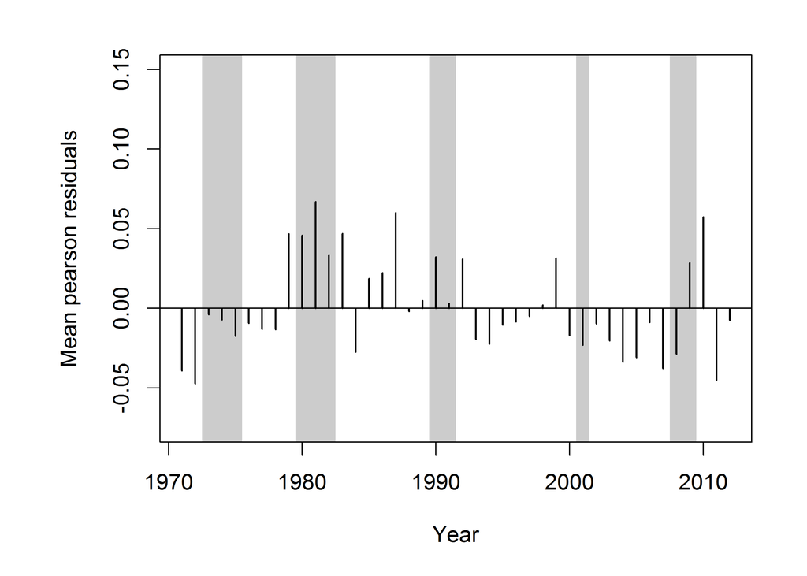

### Time-varying

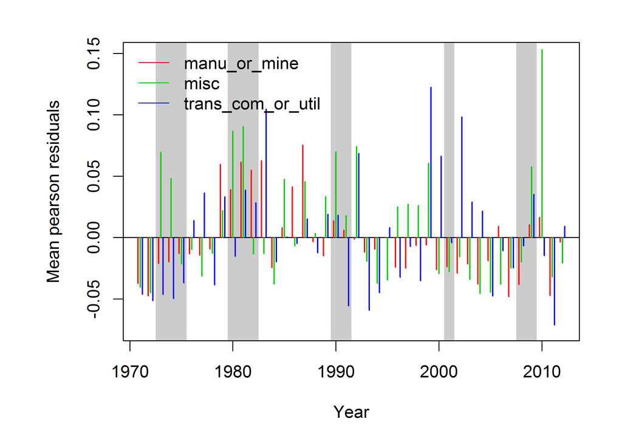

Similar industry definitions as Chava and Jarrow (2004)

### Time-varying

Additive Hazards Models Lando, Medhat, Nielsen, and Nielsen (2013) using `timereg` package described in Martinussen and Scheike (2007)

Semiparametric Cox Model Grambsch and Therneau (1994) scaled schoenfeld residuals

### Dynamic binary regression models

\[ \begin{aligned} &\vec{\alpha}_t = \mat{F}\vec{\alpha}_{t-1} + \mat{R}\vec{\epsilon}_t, \qquad \vec{\epsilon}_t \sim N(\vec{0}, \mat{Q}) \\ &\mat{F} = \mat{R} = \mat{I} \end{aligned} \]

\[ \begin{aligned} &\expecpCond{\vec{y}_t}{\vec{\alpha}_t} = \vec{z}_t(\vec{\alpha}_t) \\ &\varpCond{\vec{y}_t}{\vec{\alpha}_t} = \mat{H}_t(\vec{\alpha}_t) \end{aligned} \]

\[ \begin{aligned} &z_{it}(\vec{\alpha}_t) =\expecpCond{Y_{it}}{\vec{\alpha}_t} = h(\vec{\alpha}_t^T \vec{x}_{it}) \\ &H_{ijt}(\vec{\alpha}_t) =\left\{\begin{matrix} z_{it}(\vec{\alpha}_t)(1 - z_{it}(\vec{\alpha}_t)) & i = j \\ 0 & \textrm{otherwise} \end{matrix}\right. \end{aligned} \]

### Dynamic binary regression models

\[ \begin{aligned} \mathcal{L}\Lparen{\vec{\alpha}_0, \dots, \vec{\alpha}_{d}} =& \log L \Lparen{\vec{\alpha}_0, \dots, \vec{\alpha}_{d}} \\ =& -\frac{1}{2} \Lparen{\vec{\alpha}_0 - \vec{a}_0}^T \mat{Q}^{-1}_0\Lparen{\vec{\alpha}_0 - \vec{a}_0} \\ & - \frac{1}{2} \sum_{t = 1}^d \Lparen{\vec{\alpha}_t - \mat{F}\vec{\alpha}_{t - 1}}^T\mat{R}\mat{Q}^{-1}\mat{R}^\top \Lparen{\vec{\alpha}_t - \mat{F}\vec{\alpha}_{t - 1}} \\ & - \frac{1}{2} \log \deter{\mat{Q}_0} - \frac{1}{2d} \log \deter{\mat{Q}} \\ & + \sum_{t = 1}^d \sum_{i \in R_t} l_{it}({\vec{\alpha}_t}) \end{aligned} \]

\[ l_{it}(\vec{\alpha}_t) = y_{it} \log h(\vec{x}_{it}^T \vec{\alpha}_t) + (1 - y_{it}) \log \Lparen{1 - h(\vec{x}_{it}^T \vec{\alpha}_t)} \]

### Extended Kalman Filter

\[ \emNotee{\vec{a}}{t}{s} = \expecpCond{\vec{\alpha}_t}{\vec{y}_1,\dots,\vec{y}_s}, \qquad \emNotee{\mat{V}}{t}{s} = \expecpCond{\mat{V}_t}{\vec{y}_1,\dots,\vec{y}_s} \]

Prediction step

\[ \emNotee{\vec{a}}{t}{t - 1} = \mat{F} \emNotee{\vec{a}}{t - 1}{t - 1}, \qquad \emNotee{\mat{V}}{t}{t - 1} = \mat{F}\emNotee{\mat{V}}{t - 1}{t - 1}\mat{F}^T + \mat{R}\mat{Q}\mat{R}^T \]

Correction step

\[ \emNotee{\mat{V}}{t}{t} = \left( \emNotee{\mat{V}}{t}{t - 1}^{-1} + \mat{U}_t (\emNotee{\vec{a}}{t}{t - 1})\right)^{-1}, \qquad \emNotee{\vec{a}}{t}{t} = \emNotee{\vec{a}}{t}{t - 1} + \emNotee{\mat{V}}{t}{t}\vec{u}_t (\emNotee{\vec{a}}{t}{t - 1}) \]

\[ \begin{aligned} & \vec{u}_t (\vec{\alpha}_t) = \sum_{i \in R_t} \vec{u}_{it} (\vec{\alpha}_t), \quad\vec{u}_{it} (\vec{\alpha}_t)= \left. \vec{x}_{it} \frac{\partial h(\eta)/ \partial \eta}{H_{iit}(\vec{\alpha}_t)} \Lparen{y_{it} - h(\eta)} \right\vert_{\eta = \vec{x}_{it}^T \vec{\alpha}_t} \\ & \mat{U}_t (\vec{\alpha}_t) = \sum_{i \in R_t} \mat{U}_{it} (\vec{\alpha}_t), \quad \mat{U}_{it} (\vec{\alpha}_t) = \left. \vec{x}_{it} \vec{x}_{it}^T \frac{\left( \partial h(\eta)/ \partial \eta \right)^2}{H_{iit}(\vec{\alpha}_t)} \right\vert_{\eta = \vec{x}_{it}^T \vec{\alpha}_t} \end{aligned} \]

### Smoother and M-step

Smoother

\[ \begin{aligned} & \mat{B}_t^{(k)} = \emNotee{\mat{V}}{t - 1}{t - 1} \mat{F} \emNotee{\mat{V}}{t}{t - 1}^{-1} \\ & \emNote{\vec{a}}{t - 1}{d}{k} = \emNotee{\vec{a}}{t - 1}{t - 1} + \mat{B}_t ( \emNote{\vec{a}}{t}{d}{k} - \emNotee{\vec{a}}{t}{t - 1}) \\ & \emNote{\mat{V}}{t - 1}{d}{k} = \emNotee{\mat{V}}{t - 1}{t - 1} + \mat{B}_t ( \emNote{\mat{V}}{t}{d}{k} - \emNotee{\mat{V}}{t}{t - 1}) \mat{B}_t^T \end{aligned} \qquad t = d,d-1,\dots, 1 \]

M-step

\[ \begin{aligned} \widehat{\vec{\alpha}}_0^{(k)} &= \emNote{\vec{a}}{0}{d}{k} \\ \widehat{\mat{Q}}^{(k)} &= \frac{1}{d} \sum_{t = 1}^d \mat{R}^T\left( \left( \emNote{\vec{a}}{t}{d}{k} - \mat{F}\emNote{\vec{a}}{t - 1}{d}{k} \right) \left( \emNote{\vec{a}}{t}{d}{k} - \mat{F}\emNote{\vec{a}}{t - 1}{d}{k} \right)^T \right. \\ &\hspace{57pt} + \emNote{\mat{V}}{t}{d}{k} - \mat{F}\mat{B}_t^{(k)}\emNote{\mat{V}}{t}{d}{k} - \left( \mat{F}\mat{B}_t^{(k)}\emNote{\mat{V}}{t}{d}{k} \right) ^T + \mat{F}\emNote{\mat{V}}{t - 1}{d}{k}\mat{F}^T \left. \vphantom{\left( \emNote{\vec{a}}{t}{d}{k} - \mat{F}\emNote{\vec{a}}{t - 1}{d}{k} \right)^T} \right)\mat{R} \end{aligned} \]

Fahrmeir (1992) and Fahrmeir (1994)

### Example: PBC

- Mayo Clinic trial in primary biliary cirrhosis (PBC) of the liver
- Randomized placebo controlled trial
- Both time-varying and time-invariant covariates

### Example: PBC

| id | tstart | tstop | death | trt | sex | protime | bili |
| --- | --- | --- | --- | --- | --- | --- | --- |
| 1 | 0 | 192 | 0 | 1 | f | 12.2 | 14.5 |
| 1 | 192 | 400 | 2 | 1 | f | 11.2 | 21.3 |
| 2 | 0 | 182 | 0 | 1 | f | 10.6 | 1.1 |
| 2 | 182 | 365 | 0 | 1 | f | 11.0 | 0.8 |
| 2 | 365 | 768 | 0 | 1 | f | 11.6 | 1.0 |
| 2 | 768 | 1790 | 0 | 1 | f | 10.6 | 1.9 |
| 2 | 1790 | 2151 | 0 | 1 | f | 11.3 | 2.6 |
| 2 | 2151 | 2515 | 0 | 1 | f | 11.5 | 3.6 |
| 2 | 2515 | 2882 | 0 | 1 | f | 11.5 | 4.2 |
| 2 | 2882 | 3226 | 0 | 1 | f | 11.5 | 3.6 |
| 2 | 3226 | 4500 | 0 | 1 | f | 11.5 | 4.6 |
| 3 | 0 | 176 | 0 | 1 | m | 12.0 | 1.4 |
| 3 | 176 | 364 | 0 | 1 | m | 12.0 | 1.1 |
| 3 | 364 | 743 | 0 | 1 | m | 12.0 | 1.5 |
| 3 | 743 | 1012 | 2 | 1 | m | 13.3 | 1.8 |

### Example: PBC

```r
library(dynamichazard)
dd_fit <- ddhazard(
  Surv(tstart, tstop, death == 2) ~ age + edema + trt +
       log(albumin) + log(protime) + log(bili), pbc2,
  id = pbc2$id, by = 100, max_T = 3600,
  Q_0 = diag(rep(100000, 7)), Q = diag(rep(0.1, 7)))

head(dd_fit$state_vecs)
```

```
     (Intercept)    age edema    trt log(albumin) log(protime) log(bili)
[1,]       -15.1 0.0491  1.40 -0.504        -3.95         4.95     0.715
[2,]       -15.1 0.0491  1.40 -0.504        -3.95         4.95     0.715
[3,]       -15.1 0.0514  1.62 -0.470        -4.07         4.93     0.725
[4,]       -14.4 0.0516  1.58 -0.404        -4.16         4.67     0.809
[5,]       -13.5 0.0534  1.69 -0.275        -4.36         4.25     0.930
[6,]       -13.0 0.0502  1.47 -0.322        -4.15         4.10     0.887
```

### Example: PBC

```r
indx <- c("(Intercept)", "age",  "log(bili)" )
dd_fit$state_vars[indx, indx, 1:3]
```

```
, , 1

            (Intercept)       age log(bili)
(Intercept)     19.6937 -0.033733  0.192556
age             -0.0337  0.000438  0.000903
log(bili)        0.1926  0.000903  0.095701

, , 2

            (Intercept)       age log(bili)
(Intercept)     16.4838 -0.030800  0.071646
age             -0.0308  0.000373  0.000608
log(bili)        0.0716  0.000608  0.065431

, , 3

            (Intercept)       age log(bili)
(Intercept)     14.1543 -0.028558  0.022379
age             -0.0286  0.000339  0.000594
log(bili)        0.0224  0.000594  0.054981
```

### Example: PBC

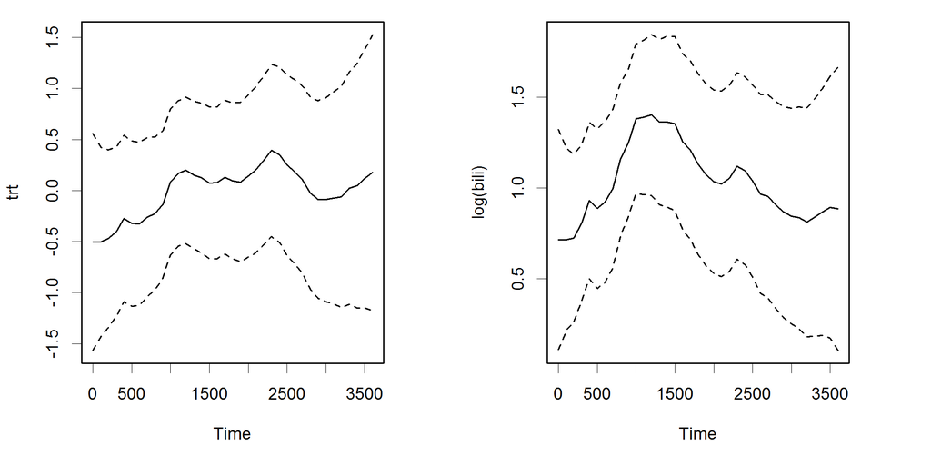

```r
plot(dd_fit, cov_index = c(4, 7))
```

### Advantages

- Linear complexity in time and observations
- Extrapolation
- `C++`, `Armadillo` and in parallel

### Unscented Kalman filter

- Deterministically select *sigma points*
- Derivative free
- Nonlinearities

Julier and Uhlmann (1997), Wan and Merwe (2000), Julier and Uhlmann (2004) and Menegaz (2016)

### Unscented Kalman filter

Prediction step

\[ \begin{aligned} &\emNotee{\vec{a}}{t}{t - 1} = \mat{F} \emNotee{\vec{a}}{t - 1}{t - 1}, \quad \\ &\emNotee{\mat{V}}{t}{t - 1} = \mat{F}\emNotee{\mat{V}}{t - 1}{t - 1}\mat{F}^T + \mat{R}\mat{Q}\mat{R}^T \end{aligned} \]

Sigma points and weights

\[ q=\text{dim}(\vec{a}), \qquad i = 1,\dots, 2q \]

\[ \begin{aligned} \wvec{a}_0 &= \emNotee{\vec{a}}{t}{t-1} \\ \wvec{a}_{i} &= \emNotee{\vec{a}}{t}{t-1} + \Lparen{1 - 2 \cdot 1_{\{i > q\}}}\sqrt{q + \lambda} \left(\sqrt{\emNotee{\mat{V}}{t}{t - 1}}\right)_i \end{aligned} \qquad \lambda = \alpha^2 (q + \kappa) - q \]

\[ \begin{aligned} &W_0^{(m)} = \frac{\lambda}{q + \lambda}, \qquad W_0^{(c)} = \frac{\lambda}{q + \lambda} + 1 - \alpha^2 + \beta, \qquad W_0^{(cc)} = \frac{\lambda}{q + \lambda} + 1 - \alpha \\ &W_i^{(m)} = W_i^{(c)} = \frac{1}{2(q+\lambda)} \end{aligned} \]

### Unscented Kalman filter

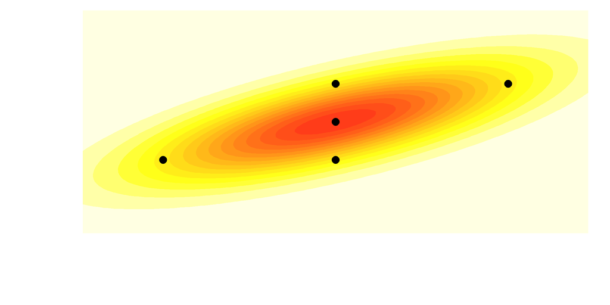

### Unscented Kalman filter

Correction step

\[ \begin{aligned} \emNotee{\vec{a}}{t}{t} &= \emNotee{\vec{a}}{t}{t - 1} + \ukfNotee{x}{y}{t}\ukfNotee{y}{y}{t}^{-1}(\vec{y}_t - \overline{\vec{y}}) \\ \emNotee{\mat{V}}{t}{t} &= \emNotee{\mat{V}}{t}{t-1} - \ukfNotee{x}{y}{t}\ukfNotee{y}{y}{t}^{-1}\ukfNotee{x}{y}{t}^T \end{aligned} \]

\[ \begin{aligned} \wvec{y}_i &= \vec{z}_t \left(\wvec{a}_i \right), \qquad \wmat{Y} = (\wvec{y}_0, \dots, \wvec{y}_{2q}) \\ \overline{\vec{y}} &= \sum_{i = 0}^{2q} W_i^{(m)} \vec{y}_i, \qquad \Delta\wmat{Y} = \wmat{Y} - \overline{\vec{y}} \vec{1}^T, \qquad \wmat{H} = \sum_{i=0}^q W_i^{(c)}\mat{H}_t(\wmat{a}_i) \\ % \Delta\wmat{A} &= (\wvec{a}_0, \dots, \wvec{a}_{2q}) - \emNotee{\vec{a}}{t}{t-1}\vec{1}^T \\ % \ukfNotee{y}{y}{t} &= \sum_{i=0}^{2q} W_i^{(c)} \left( (\wvec{y}_i - \overline{\vec{y}})(\wvec{y}_i - \overline{\vec{y}})^T + \wmat{H}\right) = \Delta\wmat{Y}\diag{\vec{W}^{(c)}}\Delta\wmat{Y}^T + \wmat{H} \\ \ukfNotee{x}{y}{t} &= \sum_{i=0}^{2q} W_i^{(cc)} (\wvec{a}_i - \emNotee{\vec{a}}{t}{t-1})(\wvec{y}_i - \overline{\vec{y}})^T = \Delta\wmat{A}\diag{\vec{W}^{(cc)}}\Delta\wmat{Y}^T \end{aligned} \]

### Unscented Kalman filter — Alternative

Correction step

\[ \begin{aligned} \tilde{\vec{y}} &= \Delta \wmat{Y}^T \widehat{\mat{H}}^{-1}(\vec{y}_t - \overline{\vec{y}}) \\ \mat{G} &= \Delta\wmat{Y}^T\widehat{\mat{H}}^{-1}\Delta\wmat{Y} \\ \vec{c} &= \tilde{\vec{y}} - \mat{G}\left( \diag{\vec{W}^{(m)}}^{-1} + \mat{G}\right)^{-1} \tilde{\vec{y}} \\ \mat{L} &= \mat{G} - \mat{G}\left( \diag{\vec{W}^{(c)}}^{-1} + \mat{G}\right)^{-1} \mat{G} \\ \emNotee{\vec{a}}{t}{t} &= \emNotee{\vec{a}}{t}{t - 1} + \Delta\wmat{A}\diag{\vec{W}^{(cc)}}\vec{c} \\ \emNotee{\mat{V}}{t}{t} &= \emNotee{\mat{V}}{t}{t - 1} - \Delta\wmat{A}\diag{\vec{W}^{(cc)}}\mat{L}\diag{\vec{W}^{(cc)}}\Delta\wmat{A}^T \end{aligned} \]

### Unscented Kalman filter — Cons

- Hyperparameters \( \alpha, \beta, \kappa \)
- Sensitive to \( \mat{Q}_0 \)
- Sensitive to starting value of \( \mat{Q} \)

### Demo

```r
dynamichazard::ddhazard_app()
```

### Binning

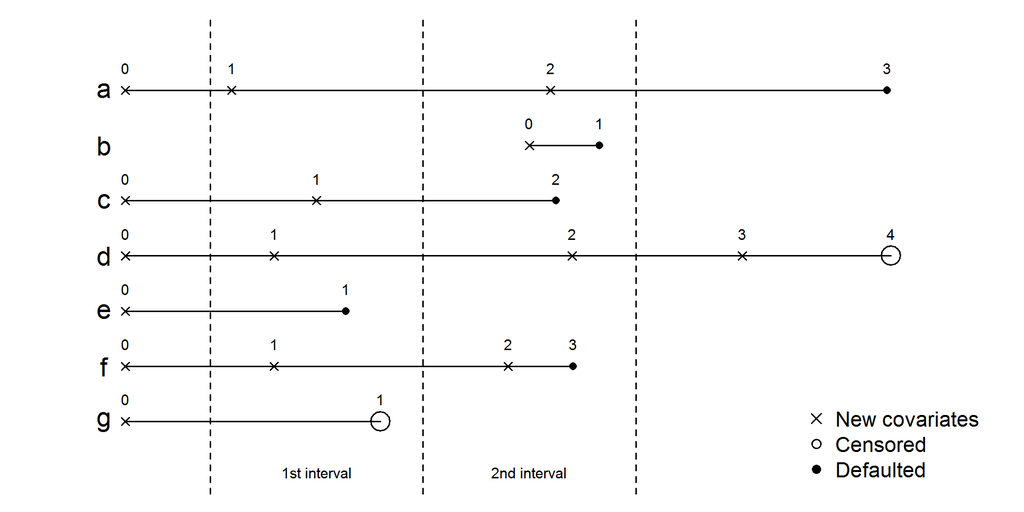

### Continuous time model

1. Coefficients change discreetly
2. Covariates change discreetly
3. Piecewise constant instantaneous hazards \( \exp(\vec{x}^\top\vec{\alpha}) \)

### Continuous time model

\[ \begin{aligned} &&T_i: &~\text{Event time of individual }i \\ &&\vec{x}_{ij}: &~j\text{'th covariate vector for individual }i\text{ valid in period }(t_{i,j-1},t_{i,j}] \\ &&l_i \in \{1, 2, \dots\}: &~\text{Number of destinct observed covariate vector for individual }i \\ &&y_{ij} = 1_{\{T_i \in (t_{i,j-1}, t_{ij}]\}} :&~ \text{Individual }i\text{ has an event with the }j\text{'th covariate vector}\\ &&\bar y_{ijs} = y_{ij} 1_{\{s-1 < t_{ij} \leq s\}} :&~\text{Individual }i\text{ has an event in interval }s \end{aligned} \]

### Continuous time model

\[ \begin{aligned} \mathcal{L}\Lparen{\vec{\alpha}_0, \dots, \vec{\alpha}_{d}} =& - \frac{1}{2} \Lparen{\vec{\alpha}_0 - \vec{a}_0}^T \mat{Q}^{-1}_0\Lparen{\vec{\alpha}_0 - \vec{a}_0} \\ & - \frac{1}{2} \sum_{t = 1}^d \Lparen{\vec{\alpha}_t - \mat{F}\vec{\alpha}_{t - 1}}^T \mat{Q}^{-1} \Lparen{\vec{\alpha}_t - \mat{F}\vec{\alpha}_{t - 1}} \\ & - \frac{1}{2} \log\deter{\mat{Q}_0} - \log\frac{1}{2d} \deter{\mat{Q}} \\ &+ \sum_{s=1}^d\sum_{(i,j) \in \Lbrace{(i,j) \left\vert\begin{smallmatrix} t_{i,j-1} < s \\ t_{i,j} > s-1 \end{smallmatrix} \right.}} l_{i,j,s}(\vec{\alpha}_s) \\ % l_{i,j,s}(\vec{\alpha}_s) =& (\vec{x}_{i,j}^T\vec{\alpha}_s)^{y_{i,j,s}} -\exp\Lparen{\vec{x}_{i,j}^T\vec{\alpha}_s} \Lparen{\min\{ s, t_{i,j} \} - \max\{ s - 1, t_{i,j-1} \}} \end{aligned} \]

### Right clipped with jump

\[ \begin{aligned} \delta_{i,j} &= t_{i,j} - t_{i,j-1} \\ % \Lambda_{ij} &= \delta_{i,j}1_{\{T_i > t_{i,j}\}} + (T_i - t_{i,j-1} - \delta_{i,j})1_{\{T_i \leq t_{i,j}\}} \\ &= \delta_{i,j}1_{\{T_i > t_{i,j}\}} + (T_i - t_{i,j}) 1_{\{T_i \leq t_{i,j}\}} = \left\{\begin{matrix}T_i - t_{i,j} & T_i \leq t_{i,j} \\ \delta_{i,j} & T_i > t_{i,j}\end{matrix} \right. \end{aligned} \]

\[ \Rightarrow \Lambda_{i,j}\in [-\delta_{i,j},0]\cup\{\delta_{i,j}\} \]

### Right clipped with jump

\[ \begin{aligned} \propp{T_i = t} &= \propp{T_i > 1} \proppCond{T_i > 2}{T_i > 1} \cdots \proppCond{T_i = t}{T_i > \lceil t \rceil - 1} \\ % &= \propp{\Lambda_{i,1} = 1} \proppCond{\Lambda_{i,2} = 1}{\Lambda_{i,2} = 1} \cdots \proppCond{ \Lambda_{i,\lceil t \rceil} = (\lceil t \rceil - 1) - t}{\Lambda_{i,\lceil t \rceil - 1} = 1)} \\ % \propp{T_i > t} &= \propp{T_i > 1} \proppCond{T_i > 2}{T_i > 1} \cdots \proppCond{T_i > t}{T_i > \lceil t \rceil - 1} \\ % &= \propp{\Lambda_{i,1} = 1} \proppCond{\Lambda_{i,2} = 1}{\Lambda_{i,2} = 1} \cdots \proppCond{ \Lambda_{i,\lceil t \rceil} > 0}{\Lambda_{i,\lceil t \rceil - 1} = 1)} \\ \end{aligned} \]

### Example: PBC

```r
dd_fit_exp <-
  ddhazard(Surv(tstart, tstop, death == 2) ~ age + edema + trt +
                        log(albumin) + log(protime) + log(bili), pbc2,
           id = pbc2$id, by = 100, max_T = 3600,

           model = "exp_clip_time_w_jump",        # <-- added

           Q_0 = diag(rep(100000, 7)),
           Q = diag(rep(0.1, 7)))
```

### Example: PBC

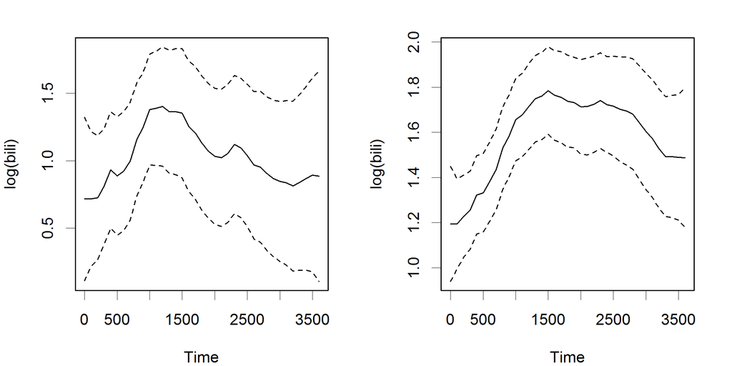

```r
plot(dd_fit, cov_index = 7)
plot(dd_fit_exp, cov_index = 7)
```

### Constant effects: E-step

- Include in state vector
- 0 entries in \( \mat{Q} \)
- Large diagonal entry in \( \mat{Q}_0 \)
- Recursive Least Squares

Harvey and Phillips (1979)

### Constant effects: M-step

\[ \vec{\alpha}_t= \begin{pmatrix} {\wtvec{\alpha}}_t \\ \vec{\gamma} \end{pmatrix} \]

### Demo

```r
dynamichazard::ddhazard_app()
```

### Future work

| Influential observation | Cumulating hat values, Pearson residuals or squared deviance residuals? |
| --- | --- |
| Posterior | Taylor expand at the posterior |
| Other processes | Replace Random walk with e.g. ARMA and parameters estimated as in MARSS library |
| Ensamble methods | Promising results (E.g. Zikeba, Tomczak, and Tomczak (2016) |
| Data sets | US, English and Danish data sets |

### References

[1] J. Y. Campbell, J. Hilscher and J. Szilagyi. “In search of distress risk”. In: *The Journal of Finance* 63.6 (2008), pp. 2899-2939.

[2] S. Chava and R. A. Jarrow. “Bankruptcy prediction with industry effects”. In: *Review of Finance* 8.4 (2004), pp. 537-569.

[3] L. Fahrmeir. “Dynamic modelling and penalized likelihood estimation for discrete time survival data”. In: *Biometrika* 81.2 (1994), pp. 317-330.

[4] L. Fahrmeir. “Posterior mode estimation by extended Kalman filtering for multivariate dynamic generalized linear models”. In: *Journal of the American Statistical Association* 87.418 (1992), pp. 501-509.

[5] P. M. Grambsch and T. M. Therneau. “Proportional hazards tests and diagnostics based on weighted residuals”. In: *Biometrika* (1994), pp. 515-526.

[6] A. C. Harvey and G. D. Phillips. “Maximum likelihood estimation of regression models with autoregressive-moving average disturbances”. In: *Biometrika* 66.1 (1979), pp. 49-58.

[7] I. Kadar, ed. *New extension of the Kalman filter to nonlinear systems*. Vol. 3068. 1997, pp. 182-193. DOI: 10.1117/12.280797. .

[8] S. J. Julier and J. K. Uhlmann. “Unscented filtering and nonlinear estimation”. In: *Proceedings of the IEEE* 92.3 (2004), pp. 401-422.

[9] D. Lando, M. Medhat, M. S. Nielsen, et al. “Additive intensity regression models in corporate default analysis”. In: *Journal of Financial Econometrics* 11.3 (2013), pp. 443-485.

[10] T. Martinussen and T. H. Scheike. *Dynamic regression models for survival data*. Springer Science & Business Media, 2007.

[11] H. M. T. Menegaz. “Unscented kalman filtering on euclidean and riemannian manifolds”. http://repositorio.unb.br/handle/10482/21617. 2016.

[12] T. Shumway. “Forecasting bankruptcy more accurately: A simple hazard model*”. In: *The Journal of Business* 74.1 (2001), pp. 101-124.

[13] T. Naito, K. Hidaka, J. Xin, et al., ed. *The unscented Kalman filter for nonlinear estimation*. 2000, pp. 153-158. DOI: 10.1109/ASSPCC.2000.882463.

[14] M. Zikeba, S. K. Tomczak and J. M. Tomczak. “Ensemble boosted trees with synthetic features generation in application to bankruptcy prediction”. In: *Expert Systems with Applications* 58 (2016), pp. 93-101.